# THE ARTOMETRICS OF MEDIA FRANCHISES

## FAST FACTS

$91B Pokémon lifetime revenue — the highest-grossing media franchise ever recorded

107 Unique franchises in the dataset, each clearing at least $4B in lifetime revenue

$4B+ Minimum threshold for inclusion — this dataset only covers the very top of the industry

8 Revenue categories tracked: Merchandise, Video Games, Box Office, Home Video, Comic/Manga, Music, TV, Book Sales

92 yrs Span of the dataset — from Winnie the Pooh (1923) to Monster Strike (2015)

## TOP 20 FRANCHISES BY TOTAL REVENUE

### Revenue Breakdown by Category, Top 20 Franchises

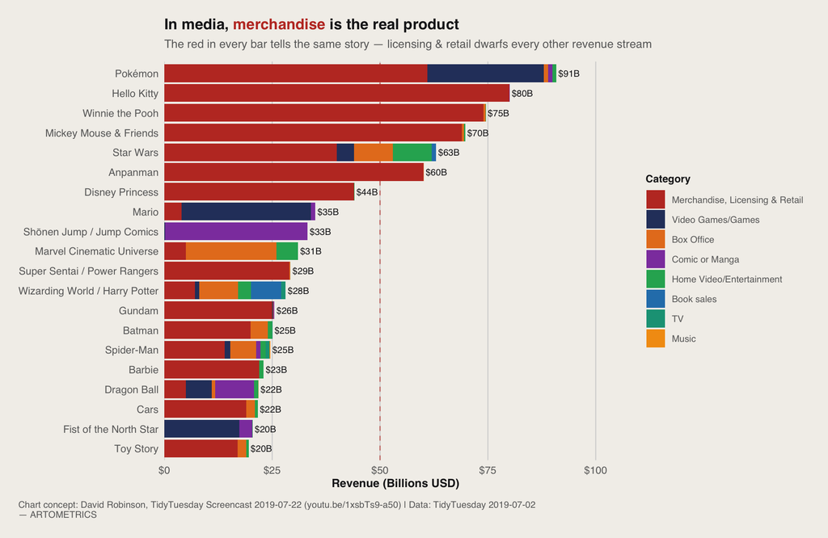

### THE RED THAT RUNS THROUGH EVERYTHING

The color logic of this chart is the argument. Merchandise, Licensing & Retail (red) dominates the fill for nearly every bar in the top 20. This is not a quirk of how Wikipedia compiles revenue figures — it is a structural feature of how large-scale media IP actually makes money. The content — the films, the games, the episodes — functions primarily as **marketing infrastructure** for the real product, which is the license. Every time a child watches a Winnie the Pooh episode, they are being cultivated as a future customer for plush animals, backpacks, and themed birthday party supplies. The entertainment is the demand generator. The merchandise is the business.

### ANPANMAN AND THE INVISIBLE GIANT

**Anpanman** at $60B is the franchise most likely to surprise a Western reader. It is entirely invisible in American pop culture, but it is one of the most dominant children’s IP properties in Japan — a bread-faced superhero created by Takashi Yanase in 1973 that appears on virtually every consumer product category in the country. Its revenue is almost entirely merchandise. Anpanman’s placement at #6, above Disney Princess, Spider-Man, and the MCU, is a useful corrective to the assumption that “global” and “valuable” are synonyms. The most commercially successful IP does not have to cross cultural borders — it just has to dominate its home market completely and then sustain that dominance across generations.

### WHAT THIS RANKING ACTUALLY MEASURES

This chart is a revenue ranking, not a cultural impact ranking, and the distinction matters. Several franchises with enormous cultural influence are absent or low here because their impact was not primarily monetized through the tracked categories. The dataset only includes franchises that crossed $4B in estimated revenue — already filtering out a massive portion of the IP landscape — and the revenue estimates themselves are Wikipedia-sourced approximations, not audited financial statements. Read this chart as a measurement of **commercial scale**, not prestige, depth of influence, or narrative quality. Those are different measurements, and they produce different rankings.

## REVENUE PER YEAR OF EXISTENCE

### Which Franchise Is the Most Efficient Money-Making Machine?

[figure not shown]

### THE EFFICIENCY REFRAME

Total revenue rewards longevity. Revenue per year rewards efficiency. These are different measurements, and the chart that results from choosing the latter produces a meaningfully different ranking — one that strips away the structural advantage of age and asks a harder question: **how much value does this franchise generate per year of its existence?** A franchise created in 1928 has had 91 years to accumulate revenue. One created in 1996 has had 23. Normalizing by time puts them on comparable footing, and the result is a reordering that surfaces some of the most analytically interesting IP in the dataset — and exposes some long-running giants for the slower earners they actually are on an annualized basis.

### THE AGE PENALTY IN REVERSE

Several franchises that ranked very high on total revenue drop significantly when normalized by time. **Hello Kitty**, second in total revenue at $80B, falls to fourth at $1.8B/yr — because it has been generating that revenue since 1974, making its 45-year run the denominator that brings the rate down. **Winnie the Pooh** and **Mickey Mouse** drop further still, not because they underperform, but because their massive lifetime totals are the product of nearly a century of operation. That is its own remarkable achievement. But the per-year lens is unforgiving to age: a franchise that earns $1B a year for 90 years scores lower on this chart than one that earns $2B a year for 25.

### WHY THE MCU SITS AT $2.8B/YR

The Marvel Cinematic Universe was launched with *Iron Man* in 2008, making it one of the youngest properties in this chart at 11 years old as of 2019. Its $2.8B/yr efficiency is explained by the most deliberate franchise engineering project in Hollywood history. Disney’s acquisition of Marvel for $4 billion in 2009 was almost immediately justified: *The Avengers* (2012) grossed over $1.5B globally on its own. By 2019 the MCU had produced 23 films with a combined box office exceeding $22B, plus merchandise, home video, and licensing revenue that multiplied the total. The MCU’s high per-year efficiency is not an accident of luck — it was the product of systematic narrative planning across multiple phases, an aggressive release cadence, and cross-film character marketing that converted every individual movie into an advertisement for the next one.

### DISNEY’S ASSEMBLY LINE: FROZEN AND CARS

Both **Frozen** and **Cars** appear on this chart at approximately $1.7B/yr, and their presence together illustrates something precise about Disney’s merchandise operation. Neither is a long-running series — Frozen debuted in 2013 and Cars in 2006, making them among the youngest IP here. Their efficiency is almost entirely merchandise-driven. **Frozen** generated more in licensing revenue than *The Avengers* in the year of its release, driven by an Elsa-branded product demand that emptied store shelves globally through 2014. **Cars** is arguably the most commercially successful Pixar franchise despite being critically underrated, because its vehicle-based IP translates into one of the highest-performing toy categories in retail history. Disney did not just make popular films. It built IP that converts into retail product with exceptional precision.

## MERCHANDISE DEPENDENCE

### How Dependent Are the Top 15 Franchises on Merch Revenue?

[figure not shown]

### THE REAL PRODUCT

This chart asks a binary question: for each franchise, how much revenue comes from merchandise, and how much from everything else combined? The answer, for most of the top 15, is that merchandise is not a revenue stream — it is the **entire business model**. The content exists to establish and sustain the characters. The characters exist to be licensed. The licenses generate the revenue. When you understand that hierarchy, the red-dominant pattern in Chart 1 stops being surprising and starts being inevitable. The entertainment industry, at its most commercially scaled, is a licensing industry that uses storytelling as its primary marketing channel.

### SHŌNEN JUMP’S MISSING BAR

**Shōnen Jump / Jump Comics** shows no visible red bar on this chart, which means its merchandise revenue is low enough to be negligible relative to its total. This is worth naming explicitly because Jump is the publisher of Dragon Ball, Naruto, One Piece, Bleach, and Hunter x Hunter — among the most culturally impactful manga franchises in history. The revenue tracked here for Jump is primarily Comic or Manga (publishing). The enormous merchandise markets that exist around Dragon Ball or Naruto are tracked under their individual franchise entries, not under the Jump umbrella. This is a data architecture point rather than an economic one — Jump’s publishing revenue is real and substantial — but it illustrates how aggregation choices shape what a chart shows.

### THE RISK STRUCTURE OF MERCH DEPENDENCE

A franchise that earns 99% of its revenue from merchandise is extraordinarily powerful when licensing markets are healthy — and extraordinarily exposed when they aren’t. Merchandise revenue is sensitive to retail distribution shifts, consumer taste changes, supply chain disruptions, and the cultural relevance cycles that determine whether a character still moves product on a store shelf. The franchises with diversified revenue — Star Wars, the MCU, Harry Potter — have more structural resilience because a box office disappointment doesn’t collapse the entire revenue stack. The franchises that are 99% merch have higher peak revenue potential but fewer places to fall back on when cultural momentum shifts. This is the trade-off the chart is quietly showing.

## ORIGIN DETERMINES INCOME

### Revenue Category by Original Media Type (Heatmap)

[figure not shown]

### ORIGIN AS DESTINY

The heatmap makes a structural argument: **the medium a franchise starts in is the primary predictor of where its revenue comes from**. This is not a coincidence of data aggregation. It is a reflection of how audience relationships form, how licensing markets develop, and how distribution channels compound over time. A franchise that starts as a manga builds its audience through reading, cultivates the kind of devoted fandom that buys character products, and enters a merchandise pipeline that has been refined over decades of Japanese pop culture publishing. A franchise that starts as a novel builds its audience through prose, generates demand for screen adaptations, and monetizes through box office and home video. The starting point creates the trajectory. The trajectory creates the revenue mix.

### NOVELS AND THE BOX OFFICE PATHWAY

The **Novel** row is the most interesting counter-pattern. It shows meaningful revenue in Book sales ($18B), TV ($5B), and Home Video/Entertainment ($13B) — but its most striking column is Box Office ($33B). No other origin category generates comparable box office revenue except Film. This reflects the consistent Hollywood appetite for literary IP as source material: the Wizarding World, Twilight, The Hunger Games, and the James Bond franchise (Ian Fleming’s novels) all began as prose and monetized primarily through theatrical adaptation. The novel-to-box-office pipeline is one of the most established in the entertainment industry, and this heatmap shows its financial footprint clearly.

## AGE VS. TOTAL REVENUE

### Do Older Franchises Make More Money?

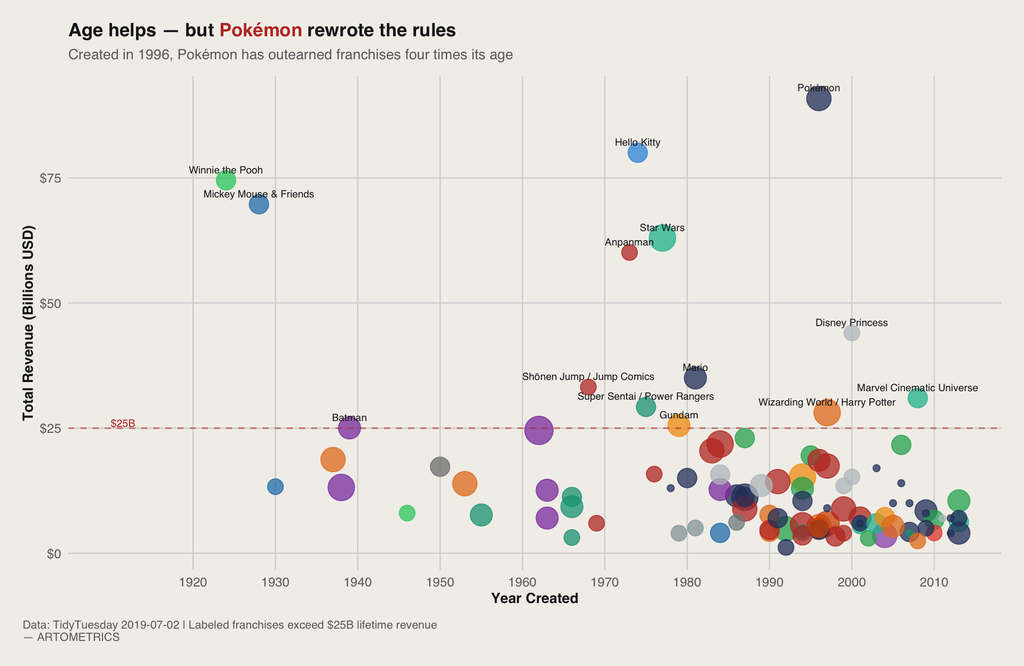

### THE GENERAL RULE

The broad pattern is real and intuitive: **older franchises tend to have higher total revenue**. This is not a profound insight on its own — more time means more years of product sales, licensing agreements, compounding brand recognition, and sequential audience generations. The upper-left quadrant of this chart (old franchises, high revenue) is where the juggernauts cluster, and the lower-right (newer franchises, lower revenue) is where the recent entrants are still building. But this baseline pattern is precisely what makes the exceptions visible and interesting. The general rule sets the expectation that Pokémon violates.

### THE PRE-1980 CLUSTER

The upper-left portion of the chart — franchises created before 1980 that have broken $25B in lifetime revenue — contains Winnie the Pooh (1923), Mickey Mouse & Friends (1928), Hello Kitty (1974), Star Wars (1977), and Anpanman (1973). What unites them is not just age but **character durability**: each is built around an IP that has maintained meaningful cultural relevance across multiple generations of audiences without requiring narrative continuity. You don’t need to have seen *Bambi* to want a Mickey Mouse hat. You don’t need to have read the original books to buy a Winnie the Pooh plush. The characters sustain demand independently of the stories — which is the prerequisite for the kind of multi-decade merchandise compounding that produces $70B+ totals.

### POKÉMON AS THE STRUCTURAL EXCEPTION

**Pokémon** — created in 1996 and sitting at $91B — is the single largest deviation from the age-revenue relationship in this dataset. It has outearned franchises that are two, three, and four times its age. Understanding why requires looking at what Pokémon was structurally designed to do: **generate collecting behavior at scale, across every age cohort, continuously**. The trading card game creates perpetual demand for new product releases. The video games create new entry points every generation of Nintendo hardware. The anime creates persistent cultural exposure for characters that drive card and game sales. Each component feeds the others in a loop that doesn’t require any single cultural moment to sustain — it just requires the system to keep running. Pokémon is an economic machine built inside an entertainment property.

### WHAT DOT SIZE TELLS YOU

The size of each dot encodes the number of revenue categories that franchise has been tracked across — larger dots have more diversified revenue streams. The biggest dots in the upper portion of the chart (Pokémon, Star Wars, Mario, Wizarding World) are the most diversified franchises and tend to be the highest earners. This is not a coincidence. **Revenue diversification and total revenue scale are correlated**: franchises that successfully extend into multiple categories tend to reach higher absolute totals, and franchises that reach higher totals tend to have the brand equity necessary to extend into multiple categories. The causality runs in both directions — scale enables diversification, and diversification protects and extends scale.

### THE CROWDED LOWER-RIGHT

The lower-right quadrant — franchises created after 1990 with revenue below $25B — is the most densely populated region of the chart. This is where the majority of the dataset lives: properties created in the last 30 years that have cleared the $4B threshold but haven’t broken into the upper tier. The density of this region is partly a cohort effect (more franchises have been created in recent decades than in earlier ones) and partly a reflection of the time required to compound. Most of these properties are still in their growth phase by 2019. Some will eventually migrate to higher revenue territory. Most will plateau where they are. The chart shows the density of the field below the $25B line, but it cannot show which properties will eventually clear it.

### IMPLICATIONS FOR NEW IP

This chart implies something uncomfortable for anyone building new IP in the 2010s: **the structural advantages of age are real, the ceiling for rapid ascent is high, and Pokémon is the exception, not the template**. Creating a franchise that reaches $25B+ within 25 years of launch requires either a fundamentally new market (which Pokémon partially benefited from in the early internet era) or a level of cross-category execution that virtually no IP development team has successfully replicated. The franchises most likely to break through are the ones that, like Pokémon, embed a behavioral loop — collecting, competing, trading, sharing — rather than relying on passive consumption alone. Passive consumption makes fans. Behavioral loops make economies.

## LIMITATIONS

This dataset reflects revenue estimates compiled from Wikipedia as of mid-2019, and carries several important caveats. Revenue figures are sourced inconsistently — some represent lifetime totals through 2019, others may reflect different windows or methodologies. Franchises are only included if they surpassed an estimated $4B threshold, meaning smaller but culturally significant IP is absent entirely. The ownership and creator fields reflect the state of the industry at the time of data collection and do not account for subsequent acquisitions — for example, the full integration of Fox assets into Disney’s portfolio, or the ongoing consolidation of gaming IP by major publishers. Revenue categories were consolidated from over 60 raw Wikipedia subcategories into 8 groups, which involves judgment calls documented in the original TidyTuesday cleaning script. The “Merchandise, Licensing & Retail” category is particularly broad and may include revenue streams that other analyses would track separately. All revenue figures should be treated as order-of-magnitude approximations rather than precise financial data.

## CONCLUSION

The media franchise landscape is not flat — it is sharply skewed toward a small number of IP that have mastered merchandise and sustained it across decades. Pokémon stands alone at the top, not because of box office dominance but because it turned a video game into the world’s most successful licensing machine while simultaneously running an anime, a card game, a stadium tour, and a global trading ecosystem. The Artometrics takeaway from this dataset is a single structural insight: **the most valuable thing a franchise can do is give people something to own, collect, and trade — not just something to watch**.

The franchises that figured this out earliest and most completely — Hello Kitty, Mickey Mouse, Winnie the Pooh — have sustained half-century revenue streams that newer IP can only aspire to. But Pokémon proved the model can be replicated at speed, at scale, and without a century of compounding time. The question for the next generation of IP is not whether to merchandise. Every major franchise already knows the answer to that. The question is whether the underlying IP can generate the kind of behavioral engagement — collecting, competing, trading, playing — that sustains merchandise demand without a continuous hit of new content to power it. The franchises that can do that don’t just make money. They become institutions.

## REFERENCES

- TidyTuesday (2019-07-02). *Media Franchise Revenues*. R for Data Science Community. Retrieved from https://github.com/rfordatascience/tidytuesday/tree/main/data/2019/2019-07-02
- Wikipedia. *List of Highest-Grossing Media Franchises*. Retrieved via TidyTuesday cleaning script (revenue.R).
- Robinson, D. (2019, July 22). *Analyzing Franchise Revenue — TidyTuesday Screencast*. YouTube. https://youtu.be/1xsbTs9-a50 — Chart 1 concept adapted from this screencast with original Artometrics styling applied.

## EDITOR’S NOTE

*This report was researched, written, designed, and produced in active collaboration with Claude AI (Anthropic). The data pipeline, statistical analysis, chart design, written analysis, narrative structure, and visual styling were all developed through a directed partnership between human editorial judgment and AI execution. Artometrics was built on the premise that rigorous analysis and honest process are not in conflict. The research questions, editorial instincts, interpretive framing, and brand vision are ours. The execution — every line of R code, every paragraph of analysis, every design decision — was a collaboration. We document this not as a disclaimer but as a description of how we actually work, and as a position: we believe this is what serious data journalism looks like when the tools available are used honestly and at full capacity.*

*— Artometrics Editorial*